# Section 1.1: Introduction to Automata

# Formal Languages and Automata

## Course Overview

- What does it mean to *compute*?
- What *features* are necessary for a machine to compute?
- What are the respective *limits* on what different machines can compute?

Topics:

- Regular Languages
- Context-Free Languages
- The Church-Turing Thesis (Turing Machines)
- Decidability (The Halting Problem)
- Reducibility
- Time Complexity (if time permits)

## Course Mechanics

- Prework
- Presentations
- Exams

## Prework

- Regular, written homework assignments
- Due prior to the next class meeting
- Scan and upload a PDF to Canvas
  - Use GeniusScan or AdobeScan or equivalent app.
- Perfection not required for full credit
  - Include questions about what you couldn’t do, along with relevant facts/definitions.

## Presentations

- You will find your name assigned to one of the prework problems, usually with others.
- You (or one of the others) will be chosen to present this problem in class.
- Make sure you know how to do these problems. Come to student hours if you need help.
- You will be presenting about one problem per week.

## Exams

- Hour Exams (3)
- Final Exam

## Student Hours

- Winter 303
- Tuesdays 1-3:20, Thursdays 2-4:40.
- Email me if you want to set up another time to meet.

# Section 1.1: Finite Automata

## Finite Automata: Example

Consider an automatic swinging door.

- The door has two states: OPEN and CLOSED.
- There are sensors in the FRONT and REAR to tell if someone is standing there.
- We want to program the door so that it opens when someone is standing in front of it, but doesn’t hit someone standing behind it.
- If BOTH sensors are activated, the door stays in its current state.
- In NEITHER sensor is activated, the door closes.

## Automatic door automaton

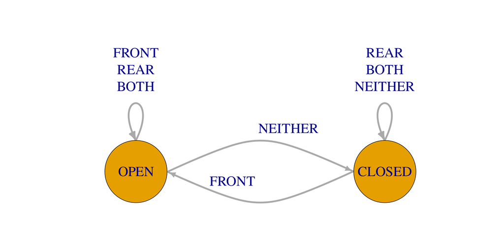

## Finite Automata as a computational model

The “machines” that we will study in this class will be very simple:

- Input: a *string* in an *alphabet* of *symbols*
  - e.g., 011001
- Output: A yes/no decision: *accept* or *reject*

## Example: Accepting and Rejecting

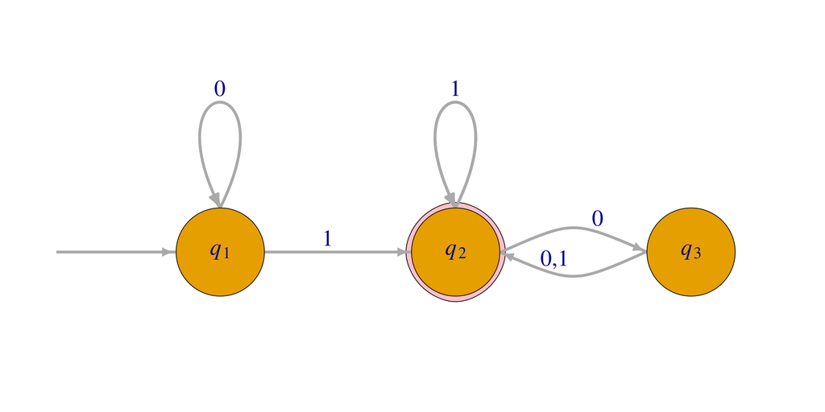

# Formal Languages

## Languages

A **language** over a set of symbols $\Sigma$ is a set of strings in those symbols.

The set of all strings that are accepted by an automaton is called the language **recognized** by the automaton.

- Given an automaton, determine the language it recognizes.
- Given a language, find an automaton that recognizes it.
- Are there languages that an automaton cannot recognize?

## Example: What language does this recognize?

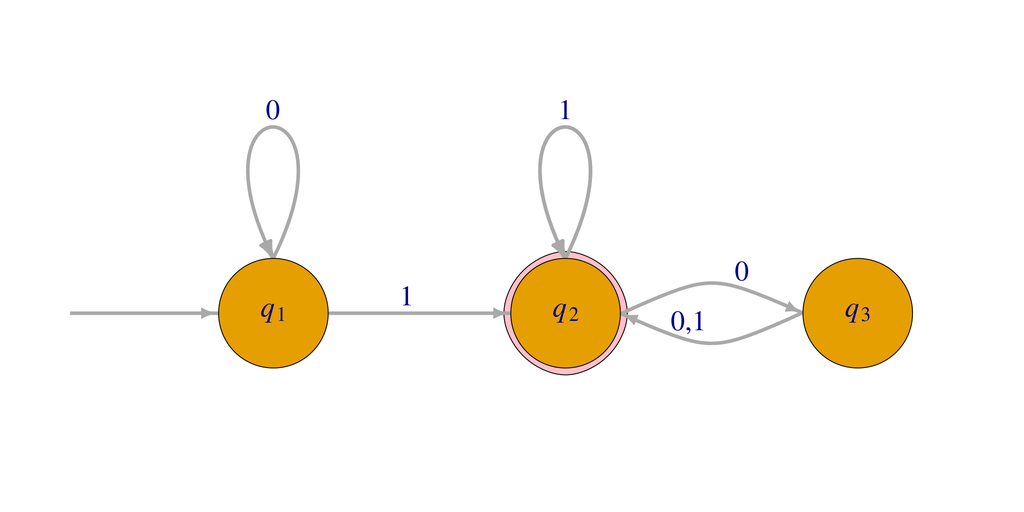

## Activity: Constructing automata

For each language in the symbols $\{\mathtt{0}, \mathtt{1}\}$, draw a state diagram for an automaton that recognizes it.

1. $\{w \mid w \text{ begins with a } \mathtt{1} \text{ and ends with a } \mathtt{0}\}$
2. $\{w \mid \text{every odd position of $w$ is a }{\mathtt{1}}\}$
3. $\{w \mid w \text{ does not contain the substring }\mathtt{110}\}$

## Formal Definition of an Automaton

A **finite automaton** is a 5-tuple $(Q, \Sigma, \delta, q_0, F)$, where

1. $Q$ is a finite set called the **states**,
2. $\Sigma$ is a finite set called the **alphabet**,
3. $\delta: Q \times \Sigma \longrightarrow Q$ is the **transition function**,
4. $q_0 \in Q$ is the **start state**, and
5. $F \subseteq Q$ is the set of **accept states**.

## Regular Languages

A language is called **regular** if some finite automaton recognizes it.